# GEO 3/430 Exercise #4

- Show All Code
- Hide All Code
- View Source

Examining Relationships Between Transportation and Health Outcomes Across Public Health Jurisdictions

Author

C. Scott Smith, PhD AICP (Instructor)

Published

February 28, 2024

# Introduction

This relatively brief exercise utilizes the [suburban Cook County Health Atlas](https://cookcountyhealthatlas.org) and [Chicago Health Atlas](https://chicagohealthatlas.org) indicators to evaluate select public health outcomes relative to transportation access and quality across Cook County. The exercise will make use of indicators derived from local surveys (i.e., [Cook County Health Survey](https://cookcountypublichealth.org/health-survey/) and the [Healthy Chicago Survey](https://www.chicago.gov/city/en/depts/cdph/supp_info/healthy-communities/healthy-chicago-survey.html)) that are administered annually by the two local health departments. Both surveys are designed to collect neighborhood-level information from residents on such things as health status, risk behaviors, and access to health care to inform and monitor the health status of communities. [Download the exercise #4 presentation](https://github.com/justenvirons/pedagogy/raw/main/docs/exercises_transportation/slides/Exercise04_Template.pptx) template to organize data elements and summaries. Submit the completed presentation to the appropriate submission folder on D2L.

# Step 1. Create a new R project

This exercise makes use of RStudio, which is available on all DePaul computers. (See download and install instructions below if you are planning to use your own laptop.) In RStudio, create a project within a new directory (e.g., GEO330/exercise_04) of a course folder on your computer. The new directory will serve as your project working directory where you will store files related to exercise #4. Create the following folders within the new exercise-specific directory: (1) “data”, (2) “images”, and (3) “scripts”.

**Install R and RStudio**

R is a free software environment for statistical computing and graphics. It compiles and runs on a wide variety of UNIX platforms, Windows and MacOS. You can download and install R via the [R Archive Network](https://cloud.r-project.org/) web pages.

RStudio is an integrated development environment (IDE) for R. It has a set of tools built to help R users be more productive with R (and other languages including Python)). It includes a console, syntax-highlighting editor that supports direct code execution. It also features tools for plotting, viewing history, debugging and managing your workspace. You can download RStudio via the [Posit website](https://posit.co/downloads/).

# Step 2. Create a new R script

In the “Files” tab of your RStudio interface (conventionally located on the bottom left screen), navigate to the “scripts” folder in your working directory. Create a new R script in the “scripts” directory and assign it an intuitive name (e.g., “Exercise_04.R”). You will use this script to manage and execute code all code for this exercise.

# Step 3. Install and activate R packages

We will use several R packages to complete the exercise, including “tigris”, “httr”, “biscale”, “jsonlite”, “dplyr”, “tidyverse” and “sf”. Copy and paste the following code to activate the associated packages in R. It may also be necessary to install the packages prior to activating. If so, uncomment the installation function.

```r
# install.packages(c("dplyr", "httr", "jsonlite", "tidyverse", "sf", "nngeo", "DT", "scales", "data.table", "tigris", "ggplot2","cowplot","corrplot", "leaflet"))

library(dplyr) # data wrangling with pipe syntax
library(httr) # tools for Working with URLs and HTTP
library(jsonlite) # managing JSON data
library(tidyverse) # data wrangling
library(sf) # simple features geometry data
library(nngeo) # perform nearest neighbor analysis
library(scales) # used for rescaling data
library(data.table) # data wrangling
library(tigris) # downloading TIGER/Line geographies from US Census
library(biscale) # bivariate mapping
library(ggplot2) # needed for bivariate mapping
library(cowplot) # needed to combine bivariate map with legend
library(corrplot) # used for creating correlation matrices

options(scipen=999, digits = 2) # format output for data tables
```

# Step 4. Review public health indicators on atlases

The [suburban Cook County](https://cookcountyhealthatlas.org) and [city of Chicago](https://chicagohealthatlas.org) health atlases are published on similar online platforms. Both atlases provide a wide array of public health indicators on a range of topics. Comprehensive data dictionaries for each of the atlases can be downloaded via the following links ([SCC atlas indicator data dictionary](https://cookcountyhealthatlas.org/api/action/download/data-dictionary/); [Chicago atlas indicator data dictionary](https://chicagohealthatlas.org/api/action/download/data-dictionary/)). For this exercise, we will be using indicators derived from each jurisdictions’ health survey. Figure 1 lists survey indicators for each of the jurisdictions along with their unique identifier keys. *Note that the following code was used to create the interactive table. It is for reference only and does not need to be copied into your custom R script.*

```r
# reference API url
topic_list_scc_url <- "https://cookcountyhealthatlas.org/api/v1/topics/?format=json&limit=400"

# download data in JSON format
topic_list_scc_json <- fromJSON(topic_list_scc_url)

# convert to dataframe
survey_topic_list_scc <- topic_list_scc_json$results %>%
  as.data.frame() %>%
  filter(str_detect(name,"CCHS") &
        is_count==FALSE) %>%
  select(name,
         key,
         description) %>%
  mutate(location = "SCC")

# reference API url
topic_list_chicago_url <- "https://chicagohealthatlas.org/api/v1/topics/?format=json&limit=400"

# download data in JSON format
topic_list_chicago_json <- fromJSON(topic_list_chicago_url)

# convert to dataframe
survey_topic_list_chicago <- topic_list_chicago_json$results %>%
  as.data.frame() %>%
  filter(str_detect(key,"HCS") &
        is_count==FALSE) %>%
  select(name,
         key,
         description) %>%
  mutate(location = "Chicago")

# bind SCC and Chicago indicator lists
survey_topic_list <- survey_topic_list_scc %>%
  bind_rows(survey_topic_list_chicago) %>%
  relocate(location, .before = name)
```

| location | name | key | description |
| --- | --- | --- | --- |
| SCC | Adult asthma rate (CCHS) | JG8UGKM | Percent of adults who reported that a doctor, nurse or other health professional has diagnosed them with asthma, and they currently have asthma. |
| SCC | Adult binge drinking rate (CCHS) | JG8IRHR | Percent of adults who report binge drinking (men having 5 or more drinks on one occasion, women having 4 or more drinks on one occasion) in the past month. |
| SCC | Adult cannabis use rate (CCHS) | JG8YUBZ | Percent of adults who reported using cannabis |
| SCC | Adult diabetes rate (CCHS) | JG8IDNP | Percent of adults who reported that a doctor, nurse or other health professional has diagnosed them with diabetes (excludes pre-diabetes or diabetes only during pregnancy). |
| SCC | Adult e-cigarette use rate (CCHS) | JG8MWEP | Percent of adults who report that they have used electronic cigarettes in the past 30 days , or Age-adjusted rate of adults who reported that they currently use electronic cigarettes "Every day" or "S… |
| SCC | Adult obesity rate (CCHS) | JG8YZKL | Percent of adults who reported having a BMI ≥ 30 |
| SCC | Adult overweight rate (CCHS) | JG8QDXC | Percent of adults who's BMI is equal to or higher than 25 but less than 30 |
| SCC | Adult physical inactivity rate (CCHS) | JG8MIQE | Percent of adults who reported that they did not participate in any physical activities or exercises in the past month. |
| SCC | Adult smoking rate (CCHS) | JG8ERVD | Percent of adults who report that they've smoked at least 100 cigarettes in their life and report that they now smoke cigarettes every day or some days. |
| SCC | Annual dental cleaning rate (CCHS) | JG8KGNL | Percent of adults who report that they have had their teeth cleaned by a dentist or hygienist in the past year. |

[output cut: 60 more lines]

Figure 1: Health Survey Indicators

# Step 5. Create novel county-wide geographic layer for mapping

Use the following code to create a novel geography (N=202) that combines city of Chicago community areas (N=77) and suburban Cook County municipalities (N=125 using 4 square mile threshold area) using GEOJSON data imported from the two health atlases. Figure 2 displays an interactive map of the new geography (i.e., “novel_geo_cook”), which includes both suburban Cook County municipalities (dark gray) and community areas (light gray).

```r
# import City of Chicago community areas (N=77) GEOJSON and transform to local projection for spatial analysis (epsg:3435)

community_areas <- st_read("https://metopio.blob.core.windows.net/lalage/atlas/3/shapes/communityareas.topo.json", quiet=TRUE) %>%
  st_as_sf() %>%
  st_set_crs(4326) %>%
  st_transform(3435) %>%
  rename(geoid = id) %>%
  mutate(geoid= str_replace(geoid,"1714000-",""),
         location = "Chicago, IL",
         type = "community area")

# import places within suburban Cook County (N=125) and transform to local projection for spatial analysis (epsg:3435)

places_cook_county <- st_read("https://metopio.blob.core.windows.net/lalage/atlas/6/shapes/SCC-place.topo.json", quiet=TRUE) %>%
  st_as_sf() %>%
  st_set_crs(4326) %>%
  st_transform(3435) %>%
  rename(geoid = id) %>%
  mutate(sqmi = as.numeric(st_area(geometry)) * 0.0000003861,
         location = "suburban Cook County",
         type = "municipality") %>%
  filter(sqmi >= 4) %>%
  select(-sqmi)

# create a novel geography in Cook County which combines both municipalities in suburban Cook County and communities areas in Chicago

novel_geo_cook <- places_cook_county %>%
  bind_rows(community_areas) %>%
  st_as_sf() %>%
  st_make_valid()
```

[interactive chart not shown]

Figure 2: Novel Cook County Geography

# Step 6. Merge suburban Cook County and city of Chicago health indicators

The next step is to download and merge similar health indicator data from the two atlases for statistical analysis and mapping. Both suburban Cook County and the city of Chicago engage in regular health surveys of their resident populations. Indicators derived from these surveys are shared on the atlas. Many of the indicators on the two atlases are aligned in such a way that allows for comparisons across jurisdictions.

The following code downloads and combines information for a selection of health survey indicators that are comparable across both atlases. Links to jurisdiction-specific thematic maps for the selected indicators are provided below. *Using the survey indicators table Figure 1 above, add two additional health indicators to the lists below. That is, add a one-word indicator name to the “a_topic_list”, and the associated indicator keys to the SCC and Chicago lists in the appropriate format.*

- Adult obesity rate ([SCC](https://cookcountyhealthatlas.org/indicators/JG8YZKL) | [Chicago](https://chicagohealthatlas.org/indicators/HCSOBP))
- Neighborhood safety rate ([SCC](https://cookcountyhealthatlas.org/indicators/JG8SRFE) | [Chicago](https://chicagohealthatlas.org/indicators/HCSNSP))
- Neighborhood sidewalk quality rate ([SCC](https://cookcountyhealthatlas.org/indicators/JG8IQGF) | [Chicago](https://chicagohealthatlas.org/indicators/HCSNSQP))
- Neighborhood violence rate ([SCC](https://cookcountyhealthatlas.org/indicators/JG8QFWF) | [Chicago](https://chicagohealthatlas.org/indicators/HCSNVP))
- Ease of walking to transit stop rate ([SCC](https://cookcountyhealthatlas.org/indicators/JG8OWII) | [Chicago](https://chicagohealthatlas.org/indicators/HCSWTSP))
- Overall health status ([SCC](https://cookcountyhealthatlas.org/indicators/JG8OLNB) | [Chicago](https://chicagohealthatlas.org/indicators/HCSOHSP))
- Physical inactivity rate ([SCC](https://cookcountyhealthatlas.org/indicators/JG8MIQE) | [Chicago](https://chicagohealthatlas.org/indicators/HCSPAP))

```r
a_topic_list <- c("obesity","safety", "sidewalk", "violence", "transit", "health", "inactivity") # edit here
a_scc_topic_keys <- c("JG8YZKL","JG8SRFE","JG8IQGF","JG8QFWF","JG8OWII","JG8OLNB","JG8MIQE") # edit here
a_chicago_topic_keys <- c("HCSOBP", "HCSNSP","HCSNSQP","HCSNVP","HCSWTSP","HCSOHSP","HCSPAP") # edit here

# download SCC health survey indicators
for (i in 1:length(a_scc_topic_keys)){

  atopic_key <- a_scc_topic_keys[i]
  atopic_name <- a_topic_list[i]

  #print(atopic_name)

  a_table_name <- paste0("scc_indicator_",atopic_name)

  a_topic_url <- paste0("https://cookcountyhealthatlas.org/api/v1/data/?format=json&layer=place&period=2022&population=&topic=",atopic_key)

  a_topic_json <- fromJSON(a_topic_url)

  a_topic_df <- a_topic_json$results %>%
    as.data.frame() %>%
   select(estimate = v,
          se = se,
          geoid = g,
          layer = l) %>%
    mutate(topic = atopic_name)

  assign(a_table_name, a_topic_df)

}

# download Chicago health survey indicators
for (i in 1:length(a_chicago_topic_keys)){

  atopic_key <- a_chicago_topic_keys[i]
  atopic_name <- a_topic_list[i]

  #print(atopic_name)

  a_table_name <- paste0("chicago_indicator_",atopic_name)

  a_topic_url <- paste0("https://chicagohealthatlas.org/api/v1/data/?format=json&layer=neighborhood&period=2021-2022&population=&topic=",atopic_key)

  a_topic_json <- fromJSON(a_topic_url)

  a_topic_df <- a_topic_json$results %>%
    as.data.frame() %>%
  select(estimate = v,
         se = se,
         geoid = g,
         layer = l) %>%
    mutate(topic = atopic_name,
           geoid= str_replace(geoid,"1714000-",""))

  assign(a_table_name, a_topic_df)

}

# bind SCC and Chicago indicators together
apattern <- "_indicator_"
alist_indicators <- mget(ls(pattern=apattern))
indicators_all <- rbindlist(alist_indicators)

# remove unneeded tables
rm(list=ls(pattern=apattern))
```

# Step 7. Join indicator attributes with county-wide geographies

```r
# reformat indicators in wide format
indicators_all_long <- indicators_all %>%
  pivot_wider(names_from = "topic", values_from = c("estimate","se")) %>%
  rename_with(~str_remove(., 'estimate_'))

# join indicator data with county-wide "novel" geography layer
indicators_all_long_geo <- novel_geo_cook %>%
  left_join(indicators_all_long, by="geoid") %>%
  st_as_sf() %>%
  drop_na(layer)
```

# Step 8. Examine statistical relationships between selected variables

```r
# subset indicator data for statistical analysis
indicators_all_long_sub <- indicators_all_long_geo %>%
  st_drop_geometry() %>%
  drop_na() %>%
  select(-starts_with("se"), -c(geoid,name,type, location,layer))

# calculate bivariate correlations between all numeric variables
variable_biv_correlations <- cor(indicators_all_long_sub, method="pearson")

# create correlation plot option 1 with correlation values
corrplot_1 <- corrplot(variable_biv_correlations, method="number", col=c("black","white"), order="hclust", bg="lightgrey", tl.col = "grey")

# create correlation plot option 2 with graduated circles
corrplot_2 <- corrplot(variable_biv_correlations, col=c("black","white"), order="hclust", bg="lightgrey", tl.col = "grey")

# display correlation plot option 1
corrplot_1

# display correlation plot option 2
corrplot_2
```

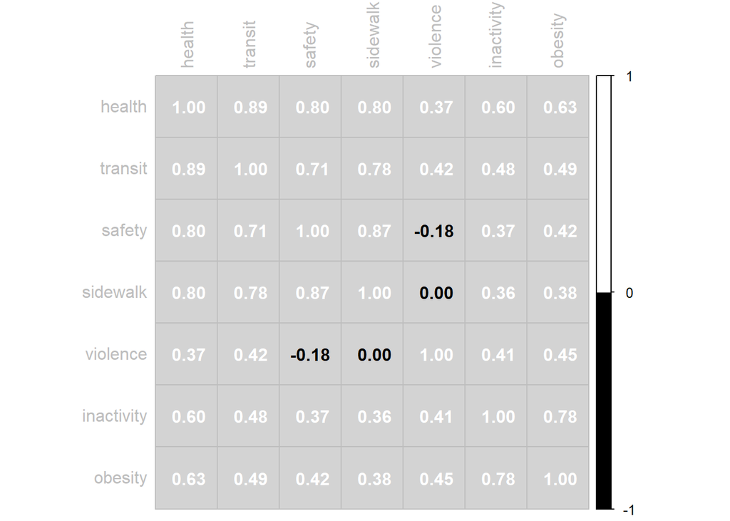

Correlation coefficients

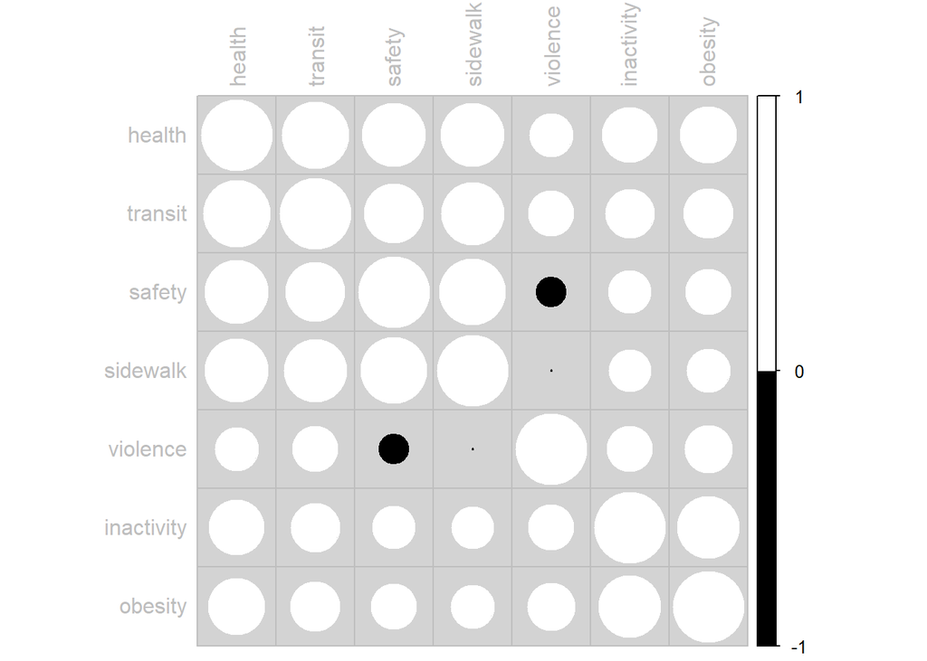

Graduated circles

Figure 3: Bivariate Correlation Plots (Pearson)

# Step 9. Create custom maps

Adapt the code below (i.e.., look for the “edit here” comments) to create two custom single variable (univariate) and bivariate thematic / choropleth maps similar to those displayed in Figure 4 and Figure 5. The univariate maps are categorized into quintiles from quintile 1 (representing the lowest performing areas) to quintile 5 (the highest performing areas). Each quintile represents about 20 percent of the geographies mapped (i.e., about 40). *Add your custom maps to slides 2-4 of your presentation and describe the spatial patterns you see in each map.*

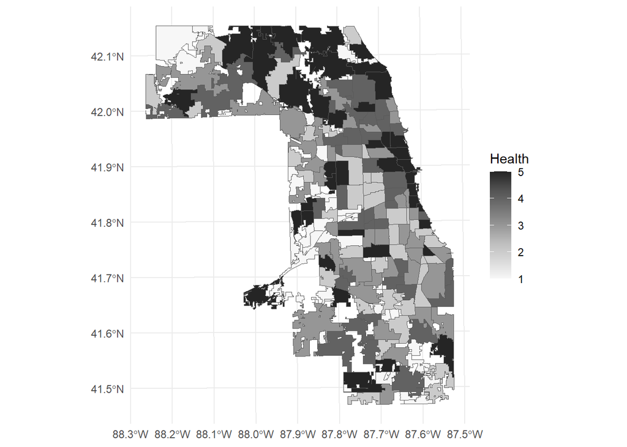

Overall health status rate

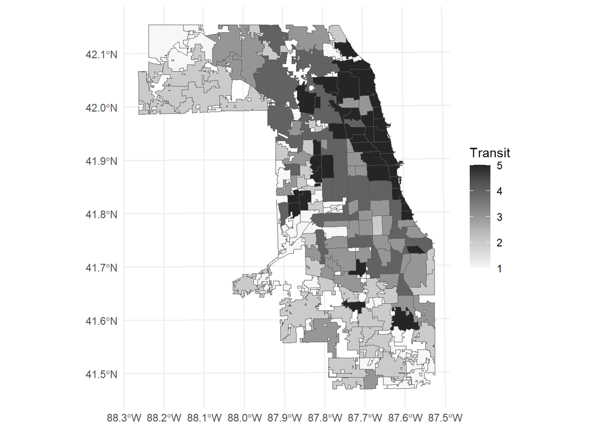

Ease of walking to transit stop rate

Figure 4: Univariate Maps (Quintile categorizations)

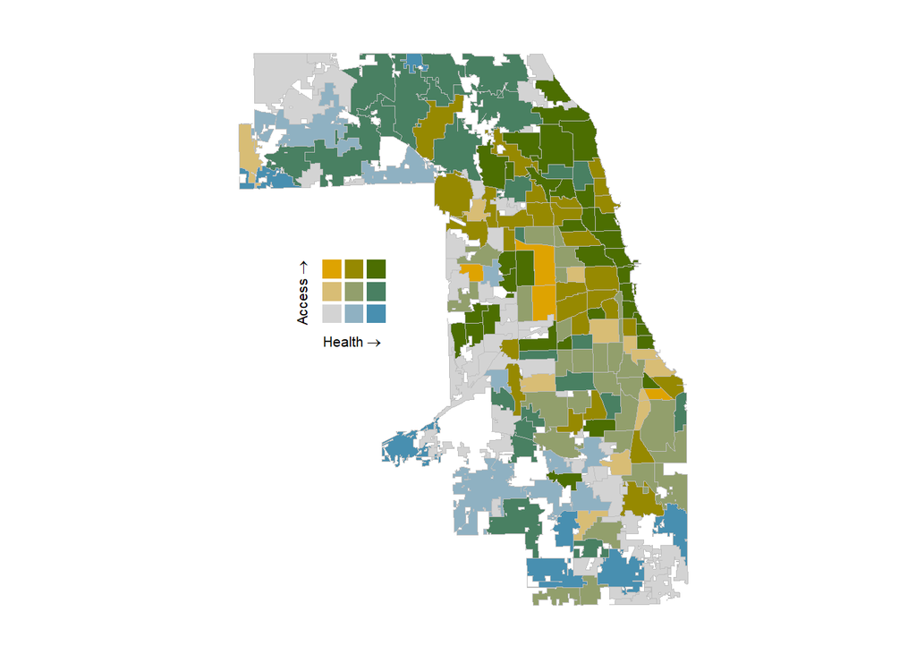

Health Status by Transit Stop Access

Figure 5: Bivariate Map

```r
# Create two custom, single variable (univariate) maps and one bivariate thematic/choropleth map # modify variable(s) to be mapped and legend names/titles for all maps

# map.HEALTH
map.Health <- ggplot() + geom_sf(data=indicators_all_long_geo,
                                  mapping = aes(fill = ntile(health, 5)), # edit here
                               size = 0.1) +
  scale_fill_distiller(name="Health", # edit here
                       palette = "Greys",
                       breaks = pretty_breaks(),
                       direction = 1) +
  theme_minimal()

# map.Transit
map.Transit <- ggplot() + geom_sf(data=indicators_all_long_geo,
                   mapping = aes(fill = ntile(transit, 5)), # edit here
                   size = 0.1) +
  scale_fill_distiller(name="Transit", # edit here
                       palette = "Greys",
                       breaks = pretty_breaks(n=4),
                       direction = 1) +
  theme_minimal()

# create custom bivariate map based on two component variables
# bivariate map data
map.bivariate.data <- bi_class(indicators_all_long_geo,
                 x = health, # edit here
                 y = transit, # edit here
                 style = "quantile", dim = 3)

# bivariate map 1 plot
# Available palettes: "Bluegill", "BlueGold", "BlueOr", "BlueYl",
# "Brown"/"Brown2", "DkBlue"/"DkBlue2", "DkCyan"/"DkCyan2",
# "DkViolet"/"DkViolet2", "GrPink"/"GrPink2", "PinkGrn", "PurpleGrn", or
# "PurpleOr"

map <- ggplot() +
  geom_sf(data = map.bivariate.data,
          mapping = aes(fill = bi_class),
          color = "grey",
          size = 0.01,
          show.legend = FALSE) +
  bi_scale_fill(pal = "BlueGold", dim = 3) +
  bi_theme()

# bivariate map 1 legend
map.legend <- bi_legend(pal = "BlueGold",
                    dim = 3,
                    xlab = "Health", # edit here
                    ylab = "Access", # edit here
                    size = 8,
                    pad_width = 1)

map.bivariate <- ggdraw() +
  draw_plot(map, 0, 0, 1, 1) +
  draw_plot(map.legend, 0.2, 0.45, 0.35, 0.2)


# display health map
map.Health

# display transit access map
map.Transit

# display bivariate map
map.bivariate
```